# Modelización ARIMA con la Serie Temporal del número de entrada de Turistas en España

## 7.4 Validación modelo 4B

**Ecuación** $ARIMA(0,1,1)(1,1,0)_{12}$:

$$(1 - \Phi_1 B^{12})(1 - B)(1 - B^{12})ln(X_t) = (1 + \theta_1 B)Z_t; Z_t
\sim N(0,0.001585)$$

con

$$\Phi_1 = -0.4108$$
$$\theta_1 = -0.6542$$

```r
val4 <- validation(mod4B)
```

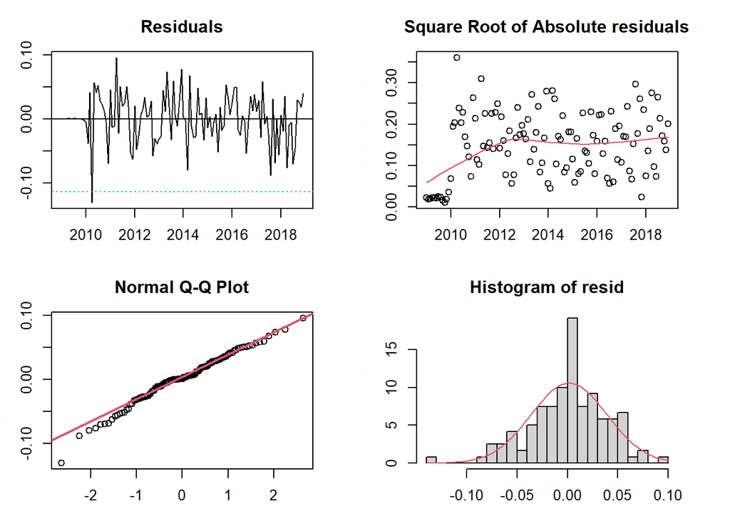

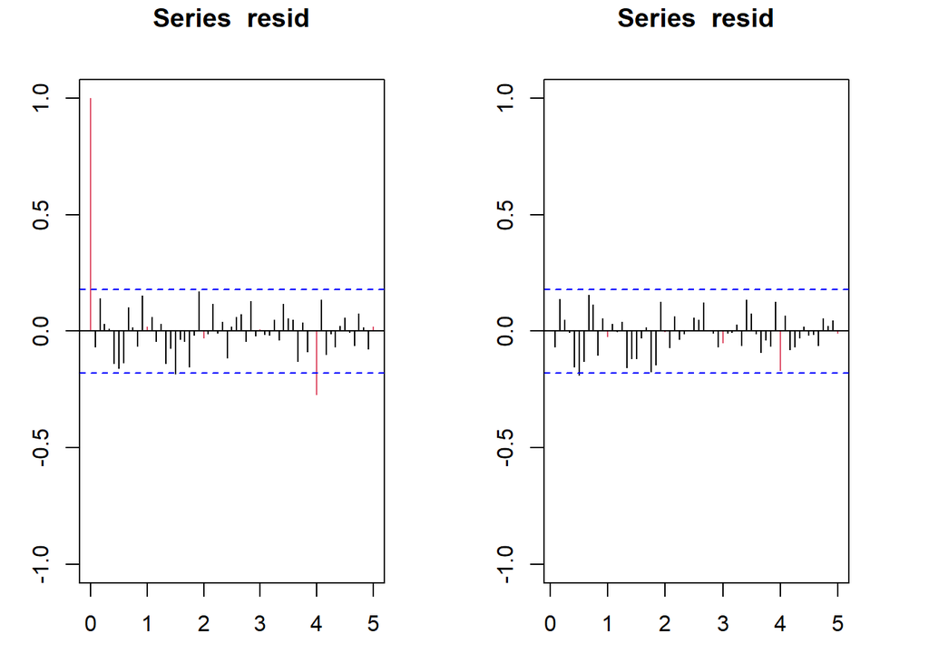

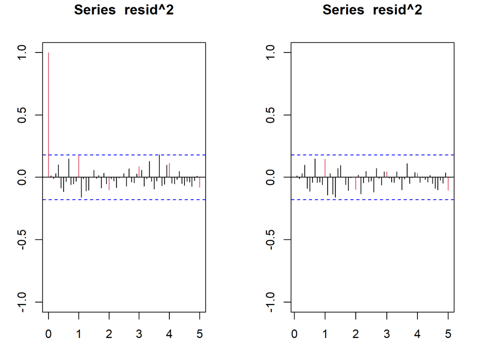

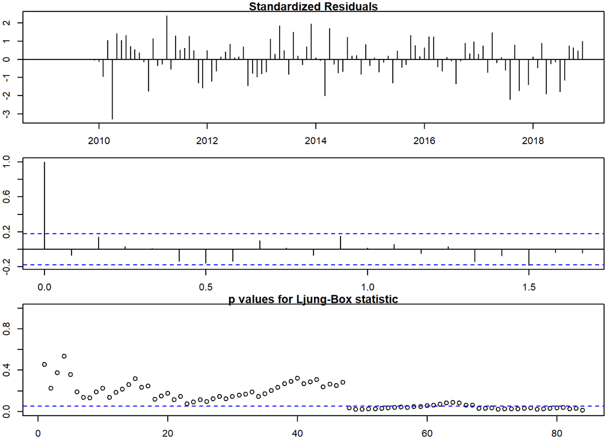

```
##
## --------------------------------------------------------------------
##
## Call:
## arima(x = lnserie, order = c(0, 1, 1), seasonal = list(order = c(1, 1, 0), period = 12))
##
## Coefficients:
##           ma1     sar1
##       -0.6542  -0.4108
## s.e.   0.0801   0.1000
##
## sigma^2 estimated as 0.001585:  log likelihood = 191.71,  aic = -377.42
##
## Modul of AR Characteristic polynomial Roots:  1.076953 1.076953 1.076953 1.076953 1.076953 1.076953 1.076953 1.076953 1.076953 1.076953 1.076953 1.076953
##
## Modul of MA Characteristic polynomial Roots:  1.528695
##
## Psi-weights (MA(inf))
##
## --------------------
##      psi 1      psi 2      psi 3      psi 4      psi 5      psi 6      psi 7
## -0.6541528  0.0000000  0.0000000  0.0000000  0.0000000  0.0000000  0.0000000
##      psi 8      psi 9     psi 10     psi 11     psi 12     psi 13     psi 14
##  0.0000000  0.0000000  0.0000000  0.0000000 -0.4108080  0.2687312  0.0000000
##     psi 15     psi 16     psi 17     psi 18     psi 19     psi 20
##  0.0000000  0.0000000  0.0000000  0.0000000  0.0000000  0.0000000
```

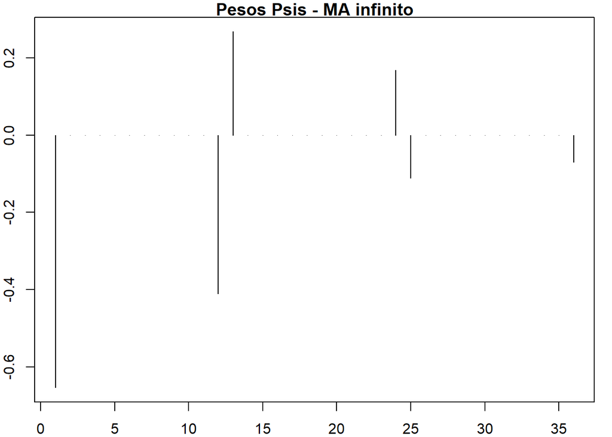

```
##
## Pi-weights (AR(inf))
##
## --------------------
##         pi 1         pi 2         pi 3         pi 4         pi 5         pi 6
## -0.654152758 -0.427915831 -0.279922321 -0.183111959 -0.119783193 -0.078356506
##         pi 7         pi 8         pi 9        pi 10        pi 11        pi 12
## -0.051257125 -0.033529989 -0.021933735 -0.014348013 -0.009385792 -0.416947751
##        pi 13        pi 14        pi 15        pi 16        pi 17        pi 18
## -0.272747521 -0.178418543 -0.116712982 -0.076348119 -0.049943333 -0.032670569
##        pi 19        pi 20
## -0.021371543 -0.013980254
```

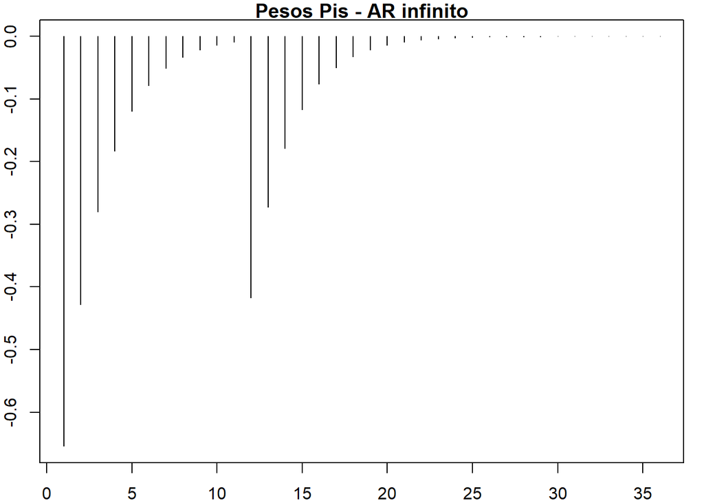

```
##
## Normality Tests
##
## --------------------
##
##  Shapiro-Wilk normality test
##
## data:  resid(model)
## W = 0.98396, p-value = 0.1655
##
##
##  Anderson-Darling normality test
##
## data:  resid(model)
## A = 0.62206, p-value = 0.103
##
##
##  Jarque Bera Test
##
## data:  resid(model)
## X-squared = 5.7478, df = 2, p-value = 0.05648
##
##
## Homoscedasticity Test
##
## --------------------
##
##  studentized Breusch-Pagan test
##
## data:  resid(model) ~ I(obs - resid(model))
## BP = 0.019484, df = 1, p-value = 0.889
##
##
## Independence Tests
## --------------------
##
##  Durbin-Watson test
##
## data:  resid(model) ~ I(1:length(resid(model)))
## DW = 2.1371, p-value = 0.7466
## alternative hypothesis: true autocorrelation is greater than 0
##
##
## Ljung-Box test
##      lag.df  statistic    p.value
## [1,]      1  0.5591044 0.45462131
## [2,]      2  3.0023998 0.22286259
## [3,]      3  3.1208220 0.37336932
## [4,]      4  3.1331471 0.53579600
## [5,]     12 16.1698768 0.18357871
## [6,]     24 33.6010916 0.09201224
## [7,]     36 42.7975220 0.20239493
## [8,]     48 67.0982731 0.03561522
```

## 7.5 Validación modelo 5B

**Ecuación** $ARIMA(0,1,1)(0,1,1)_{12}$:

$$(1 - B)(1 - B^{12})ln(X_t) = (1 + \theta_1 B)(1 + \Theta_1 B^{12})Z_t;
Z_t \sim N(0,0.001583)$$

con

$$\theta_1 = -0.6442$$
$$\Theta_1 = -0.4390$$

```r
val5 <- validation(mod5B)
```

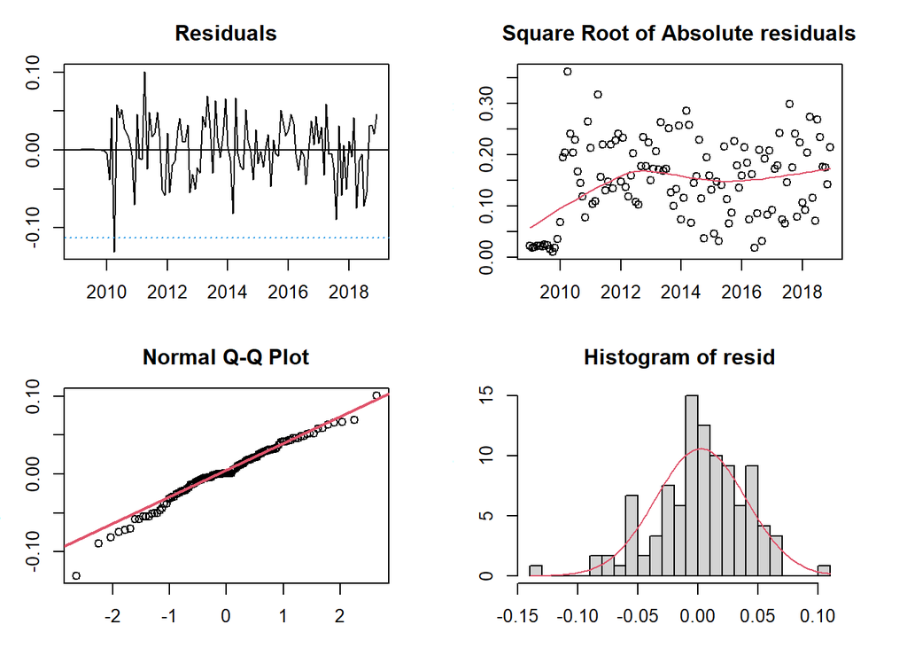

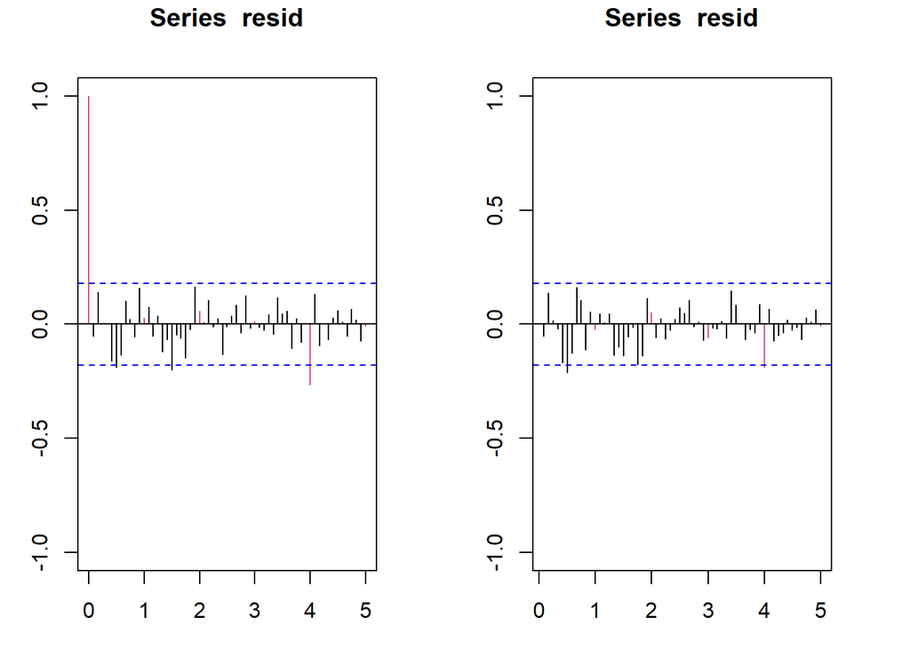

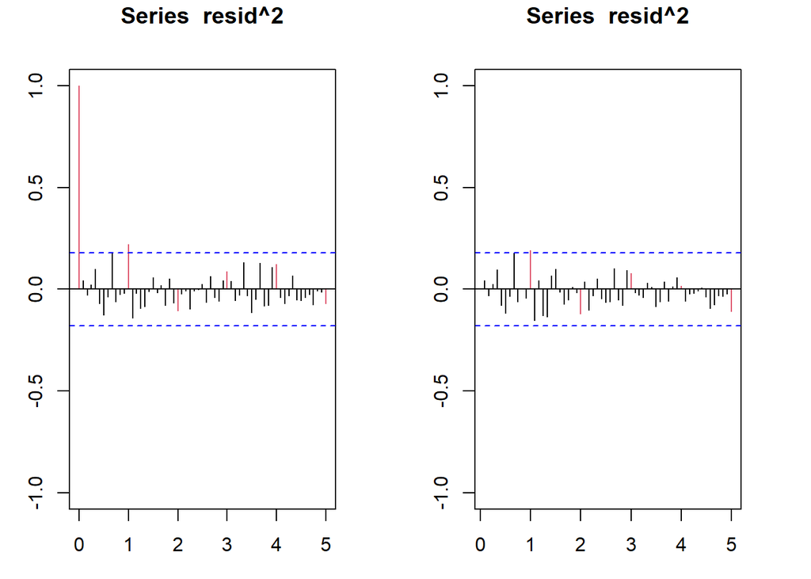

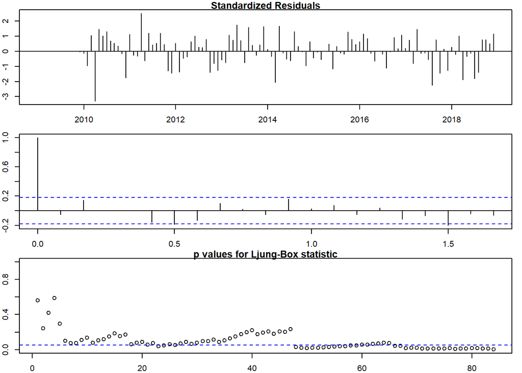

```
##
## --------------------------------------------------------------------
##
## Call:
## arima(x = lnserie, order = c(0, 1, 1), seasonal = list(order = c(0, 1, 1), period = 12))
##
## Coefficients:
##           ma1     sma1
##       -0.6442  -0.4390
## s.e.   0.0854   0.1215
##
## sigma^2 estimated as 0.001583:  log likelihood = 191.6,  aic = -377.2
##
## Modul of AR Characteristic polynomial Roots:
##
## Modul of MA Characteristic polynomial Roots:  1.071007 1.071007 1.071007 1.071007 1.071007 1.071007 1.071007 1.071007 1.071007 1.071007 1.071007 1.071007 1.552402
##
## Psi-weights (MA(inf))
##
## --------------------
##      psi 1      psi 2      psi 3      psi 4      psi 5      psi 6      psi 7
## -0.6441628  0.0000000  0.0000000  0.0000000  0.0000000  0.0000000  0.0000000
##      psi 8      psi 9     psi 10     psi 11     psi 12     psi 13     psi 14
##  0.0000000  0.0000000  0.0000000  0.0000000 -0.4390259  0.2828042  0.0000000
##     psi 15     psi 16     psi 17     psi 18     psi 19     psi 20
##  0.0000000  0.0000000  0.0000000  0.0000000  0.0000000  0.0000000
```

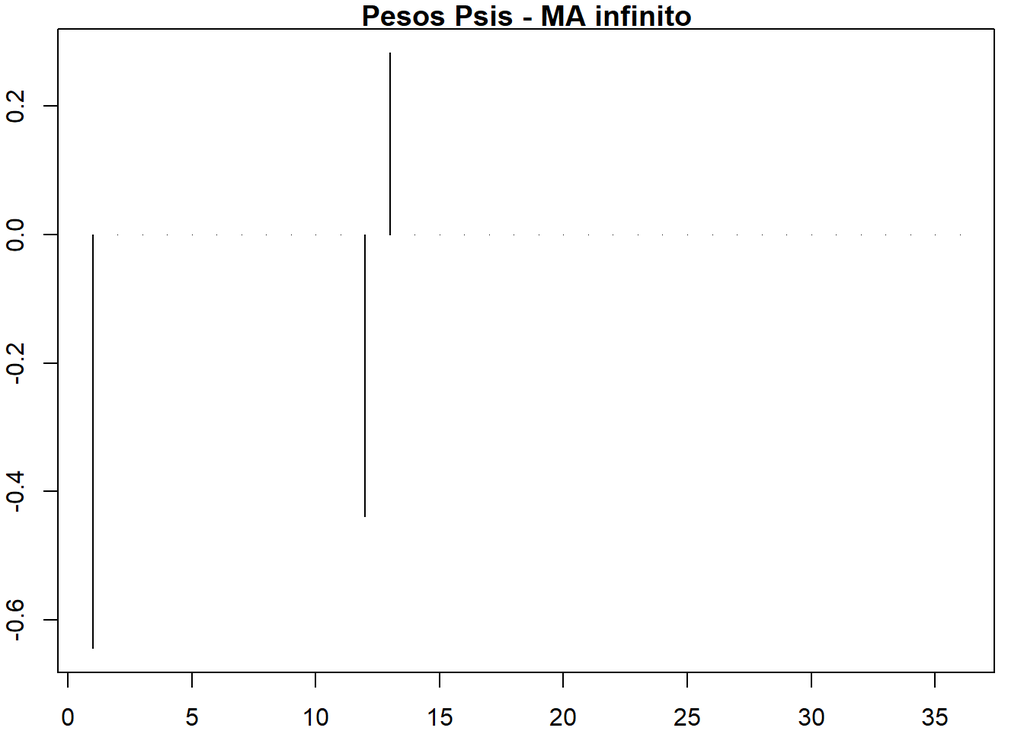

```
##
## Pi-weights (AR(inf))
##
## --------------------
##         pi 1         pi 2         pi 3         pi 4         pi 5         pi 6
## -0.644162846 -0.414945772 -0.267292649 -0.172179994 -0.110911955 -0.071445360
##         pi 7         pi 8         pi 9        pi 10        pi 11        pi 12
## -0.046022447 -0.029645950 -0.019096820 -0.012301462 -0.007924145 -0.444130380
##        pi 13        pi 14        pi 15        pi 16        pi 17        pi 18
## -0.286092290 -0.184290024 -0.118712786 -0.076470366 -0.049259369 -0.031731055
##        pi 19        pi 20
## -0.020439967 -0.013166667
```

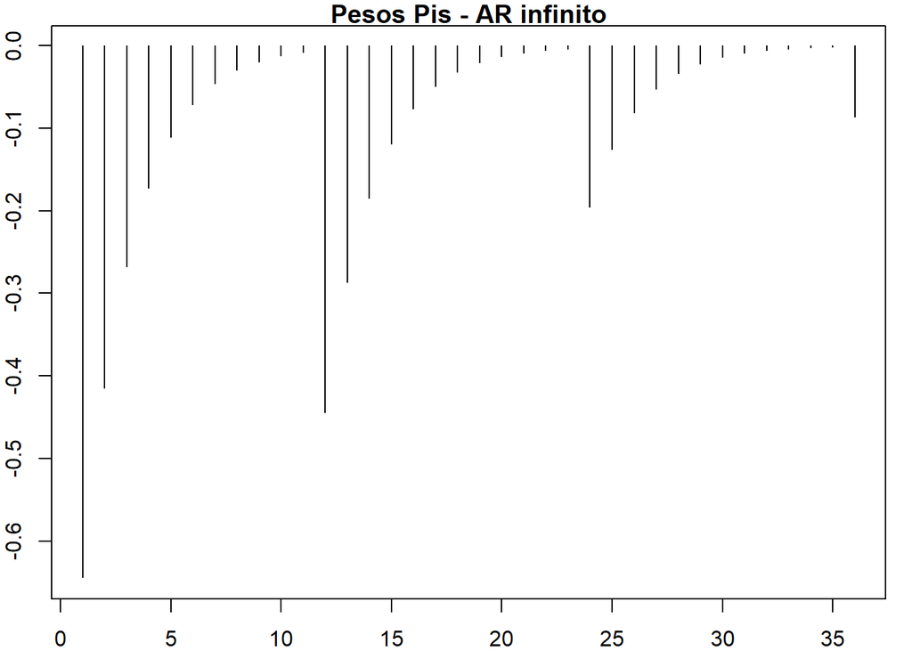

```
##
## Normality Tests
##
## --------------------
##
##  Shapiro-Wilk normality test
##
## data:  resid(model)
## W = 0.9808, p-value = 0.08446
##
##
##  Anderson-Darling normality test
##
## data:  resid(model)
## A = 0.69513, p-value = 0.06781
##
##
##  Jarque Bera Test
##
## data:  resid(model)
## X-squared = 7.2764, df = 2, p-value = 0.0263
##
##
## Homoscedasticity Test
##
## --------------------
##
##  studentized Breusch-Pagan test
##
## data:  resid(model) ~ I(obs - resid(model))
## BP = 0.079231, df = 1, p-value = 0.7783
##
##
## Independence Tests
## --------------------
##
##  Durbin-Watson test
##
## data:  resid(model) ~ I(1:length(resid(model)))
## DW = 2.1006, p-value = 0.6781
## alternative hypothesis: true autocorrelation is greater than 0
##
##
## Ljung-Box test
##      lag.df  statistic    p.value
## [1,]      1  0.3401582 0.55973789
## [2,]      2  2.8226100 0.24382489
## [3,]      3  2.8235564 0.41963678
## [4,]      4  2.8235659 0.58777170
## [5,]     12 18.3198900 0.10631715
## [6,]     24 36.7827762 0.04599217
## [7,]     36 45.8107195 0.12666973
## [8,]     48 68.0325479 0.03004847
```

## 7.6 Validación modelo 6B

**Ecuación** $ARIMA(0,1,1)(0,1,4)_{12}$:

$$(1 - B)(1 - B^{12})ln(X_t) = (1 + \theta_1 B)(1 + \Theta_1 B^{12} +
\Theta_2 B^{24} + \Theta_3 B^{36}) + \Theta_4 B^{48})Z_t; Z_t \sim
N(0,0.001173)$$

con

$$\theta_1 = -0.6638$$
$$\Theta_1 = -0.5171$$
$$\Theta_2 = 0.1805 \sim 0$$
$$\Theta_3 = -0.3242 \sim 0$$
$$\Theta_4 = -0.3392$$

```r
val6 <- validation(mod6B)
```

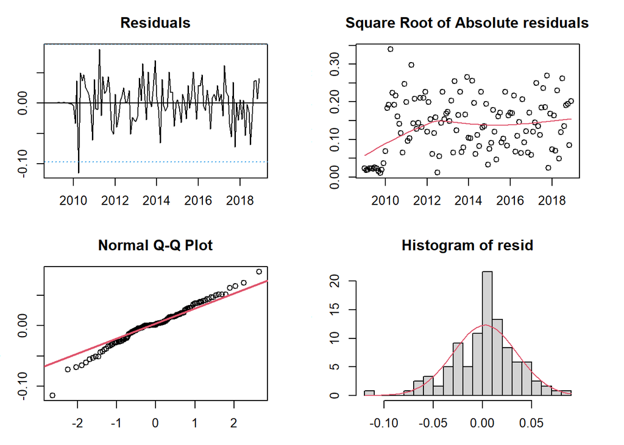

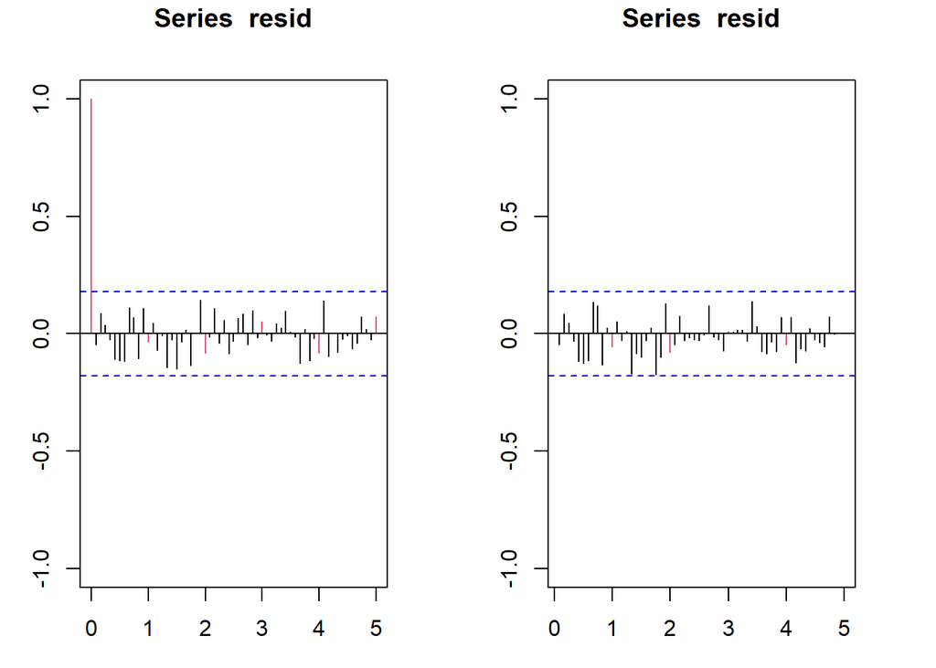

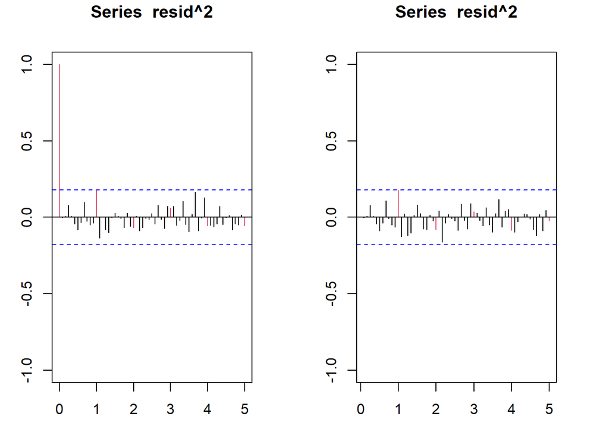

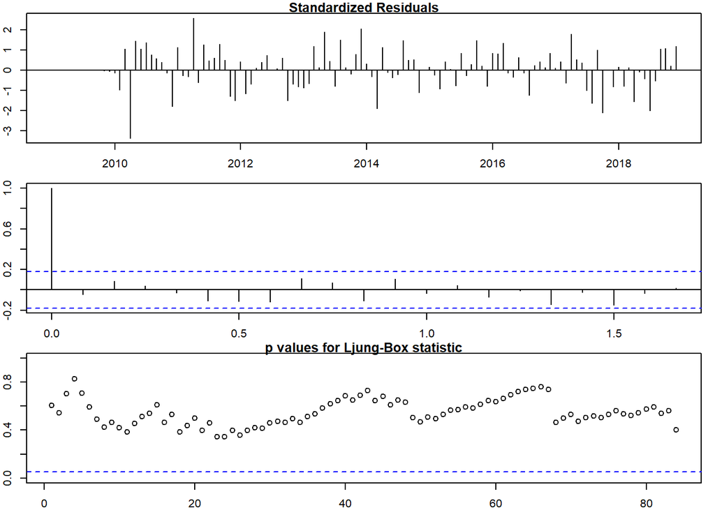

```
##
## --------------------------------------------------------------------
##
## Call:
## arima(x = lnserie, order = c(0, 1, 1), seasonal = list(order = c(0, 1, 4), period = 12))
##
## Coefficients:
##           ma1     sma1    sma2     sma3     sma4
##       -0.6638  -0.5171  0.1805  -0.3242  -0.3392
## s.e.   0.0786   0.1818  0.2013   0.2163   0.1751
##
## sigma^2 estimated as 0.001173:  log likelihood = 197.91,  aic = -383.81
##
## Modul of AR Characteristic polynomial Roots:
##
## Modul of MA Characteristic polynomial Roots:  1.016591 1 1 1 1 1.016591 1.016591 1.016591 1.016591 1.016591 1.016591 1.016591 1 1.016591 1.016591 1.016591 1.05886 1 1 1 1.05886 1.016591 1.016591 1.016591 1.016591 1.016591 1.05886 1.016591 1 1.05886 1.05886 1.05886 1.05886 1.016591 1.05886 1.01659…
##
## Psi-weights (MA(inf))
##
## --------------------
##      psi 1      psi 2      psi 3      psi 4      psi 5      psi 6      psi 7
## -0.6638091  0.0000000  0.0000000  0.0000000  0.0000000  0.0000000  0.0000000
##      psi 8      psi 9     psi 10     psi 11     psi 12     psi 13     psi 14
##  0.0000000  0.0000000  0.0000000  0.0000000 -0.5171489  0.3432882  0.0000000
##     psi 15     psi 16     psi 17     psi 18     psi 19     psi 20
##  0.0000000  0.0000000  0.0000000  0.0000000  0.0000000  0.0000000
```

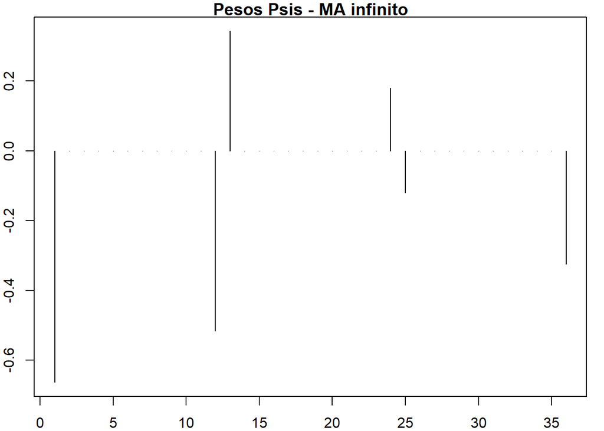

```
##
## Pi-weights (AR(inf))
##
## --------------------
##        pi 1        pi 2        pi 3        pi 4        pi 5        pi 6
## -0.66380912 -0.44064255 -0.29250255 -0.19416586 -0.12888907 -0.08555774
##        pi 7        pi 8        pi 9       pi 10       pi 11       pi 12
## -0.05679401 -0.03770038 -0.02502586 -0.01661239 -0.01102746 -0.52446907
##       pi 13       pi 14       pi 15       pi 16       pi 17       pi 18
## -0.34814735 -0.23110339 -0.15340854 -0.10183399 -0.06759833 -0.04487239
##       pi 19       pi 20
## -0.02978670 -0.01977268
```

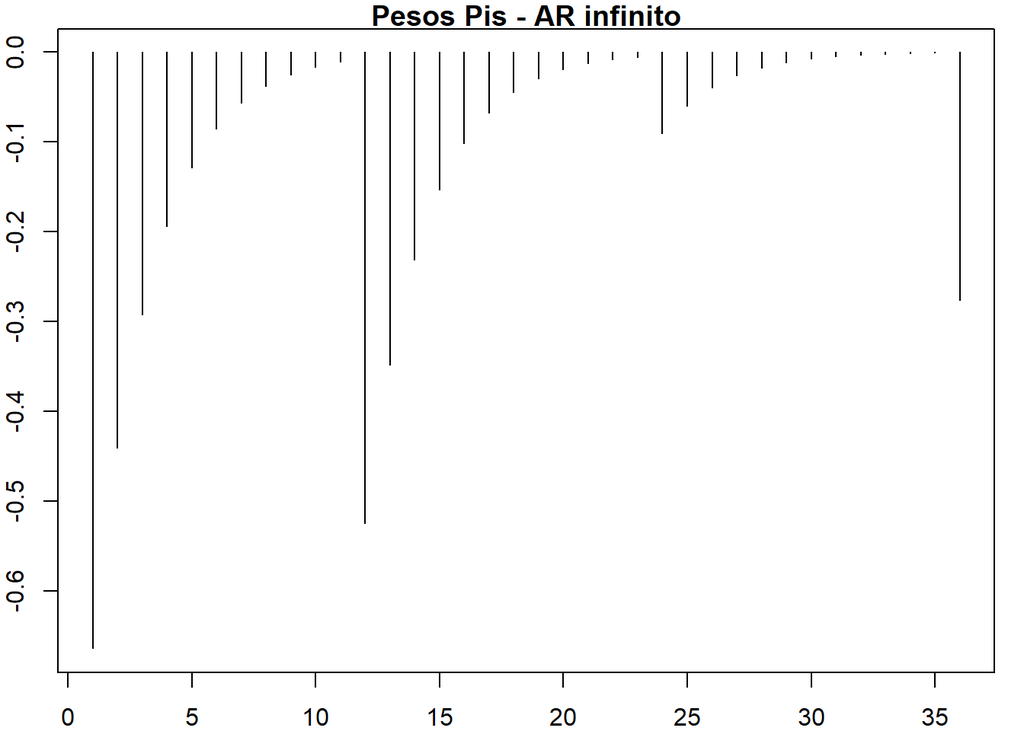

```
##
## Normality Tests
##
## --------------------
##
##  Shapiro-Wilk normality test
##
## data:  resid(model)
## W = 0.98184, p-value = 0.1056
##
##
##  Anderson-Darling normality test
##
## data:  resid(model)
## A = 0.74122, p-value = 0.05209
##
##
##  Jarque Bera Test
##
## data:  resid(model)
## X-squared = 7.7789, df = 2, p-value = 0.02046
##
##
## Homoscedasticity Test
##
## --------------------
##
##  studentized Breusch-Pagan test
##
## data:  resid(model) ~ I(obs - resid(model))
## BP = 0.1596, df = 1, p-value = 0.6895
##
##
## Independence Tests
## --------------------
##
##  Durbin-Watson test
##
## data:  resid(model) ~ I(1:length(resid(model)))
## DW = 2.0857, p-value = 0.648
## alternative hypothesis: true autocorrelation is greater than 0
##
##
## Ljung-Box test
##      lag.df  statistic   p.value
## [1,]      1  0.2684344 0.6043839
## [2,]      2  1.2224997 0.5426722
## [3,]      3  1.4064513 0.7040232
## [4,]      4  1.4947764 0.8275664
## [5,]     12 11.9058485 0.4532704
## [6,]     24 26.1776801 0.3442113
## [7,]     36 34.6069407 0.5348295
## [8,]     48 44.1122292 0.6328707
```

**Observaciones**  
-Normalidad: sí (a pesar del p-valor test Jarque-Bera)  
-Homocedasticidad: sí  
-Independencia: sí  
-Validado: SI

# Parte 8: Predicciones futuras

## 8.1 Predicciones con modelos deterministas

Usamos el filtro de Wolt-Winters para series de tipo 6 con la ecuación siguiente:

1. **Nivel (level):**

$$l_t = \alpha \frac{x_t}{s_{t-m}} + (1 - \alpha)(l_{t-1} + b_{t-1})$$

2. **Tendencia (trend):**

$$b_t = \beta (l_t - l_{t-1}) + (1 - \beta)b_{t-1}$$

3. **Estacionalidad (seasonality):**

$$s_t = \gamma \frac{x_t}{l_t} + (1 - \gamma)s_{t-m}$$

4. **Predicción (forecast):**

$$\hat{y}_{t+h} = (l_t + hb_t) s_{t+h-m(k+1)}$$

Donde:  
- $x_t$: Valor observado en el tiempo $t$.  
- $l_t$: Nivel de la serie en el tiempo $t$.  
- $b_t$: Tendencia de la serie en el tiempo $t$.  
- $s_t$: Componente estacional.  
- $m=12$: Periodo estacional.  
- $h=1,...,24$: Horizonte de predicción.  
- $\alpha, \beta, \gamma$: Parámetros de suavizado (entre 0 y 1).

```r
(hw <- HoltWinters(serie, alpha = NULL, beta = NULL, gamma = NULL, seasonal = "multiplicative"))
```

```
## Holt-Winters exponential smoothing with trend and multiplicative seasonal component.
##
## Call:
## HoltWinters(x = serie, alpha = NULL, beta = NULL, gamma = NULL,     seasonal = "multiplicative")
##
## Smoothing parameters:
##  alpha: 0.1659494
##  beta : 0.01797765
##  gamma: 1
##
## Coefficients:
##           [,1]
## a   6.63916310
## b   0.02180638
## s1  0.64164581
## s2  0.65904605
## s3  0.83253928
## s4  1.05618826
## s5  1.25630108
## s6  1.32343524
## s7  1.55868978
## s8  1.58525593
## s9  1.38532323
## s10 1.17439049
## s11 0.69252146
## s12 0.65592921
```

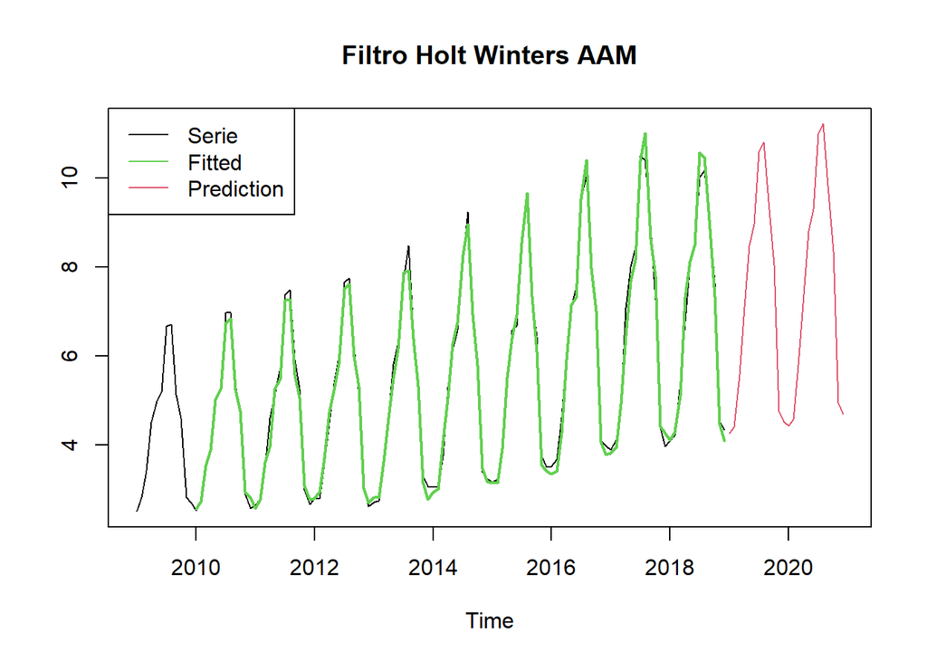

```r
predhw = predict(hw,24)
ts.plot(serie, fitted(hw)[,1], predhw, col = c(1,3,2), lwd = c(1,2), main = "Filtro Holt Winters AAM")
legend("topleft", legend = c("Serie", "Fitted", "Prediction"), col = c(1,3,2), lty = 1, bty = "y")
```

## 8.2 Predicciones con modelos ARIMA

```r
serie1=window(data, start = 2009, end = c(2019,12))   #completar la serie de 2009-2019
lnserie1=log(serie1)                                  #transformada al log
serie2=window(serie, start = 2009, end = c(2018, 12)) #serie sin las últimas observaciones: 2009-2018
lnserie2=log(serie2)                                  #transformada al log
```

### 8.2.1 Modelo 1B

#### Estabilidad del modelo

```r
(mod1B=arima(lnserie1,order=c(1,1,0),seasonal=list(order=c(1,1,0),period=12)))
```

```
##
## Call:
## arima(x = lnserie1, order = c(1, 1, 0), seasonal = list(order = c(1, 1, 0),
##     period = 12))
##
## Coefficients:
##           ar1     sar1
##       -0.5625  -0.3021
## s.e.   0.0776   0.0966
##
## sigma^2 estimated as 0.001617:  log likelihood = 212.81,  aic = -419.61
```

```r
cat("Modelo mod1B \nT-ratios:",round(mod1B$coef/sqrt(diag(mod1B$var.coef)),2))
```

```
## Modelo mod1B
## T-ratios: -7.25 -3.13
```

```r
(mod1B2=arima(lnserie2,order=c(1,1,0),seasonal=list(order=c(1,1,0),period=12)))
```

```
##
## Call:
## arima(x = lnserie2, order = c(1, 1, 0), seasonal = list(order = c(1, 1, 0),
##     period = 12))
##
## Coefficients:
##           ar1     sar1
##       -0.5581  -0.3622
## s.e.   0.0818   0.1037
##
## sigma^2 estimated as 0.001665:  log likelihood = 189.43,  aic = -372.86
```

```r
cat("Modelo mod1B2 \nT-ratios:",round(mod1B2$coef/sqrt(diag(mod1B2$var.coef)),2))
```

```
## Modelo mod1B2
## T-ratios: -6.82 -3.49
```

**Observaciones**  
Vemos que los coeficientes de los modelos son:  
- menores que uno en valor absoluto  
- no varían mucho entre los dos ajustes (con y sin los datos de 2019)  
- son del mismo signo respectivamente entre los dos ajustes  
- son significativos  
Es un modelo estable.

#### Predicción out-of-sample

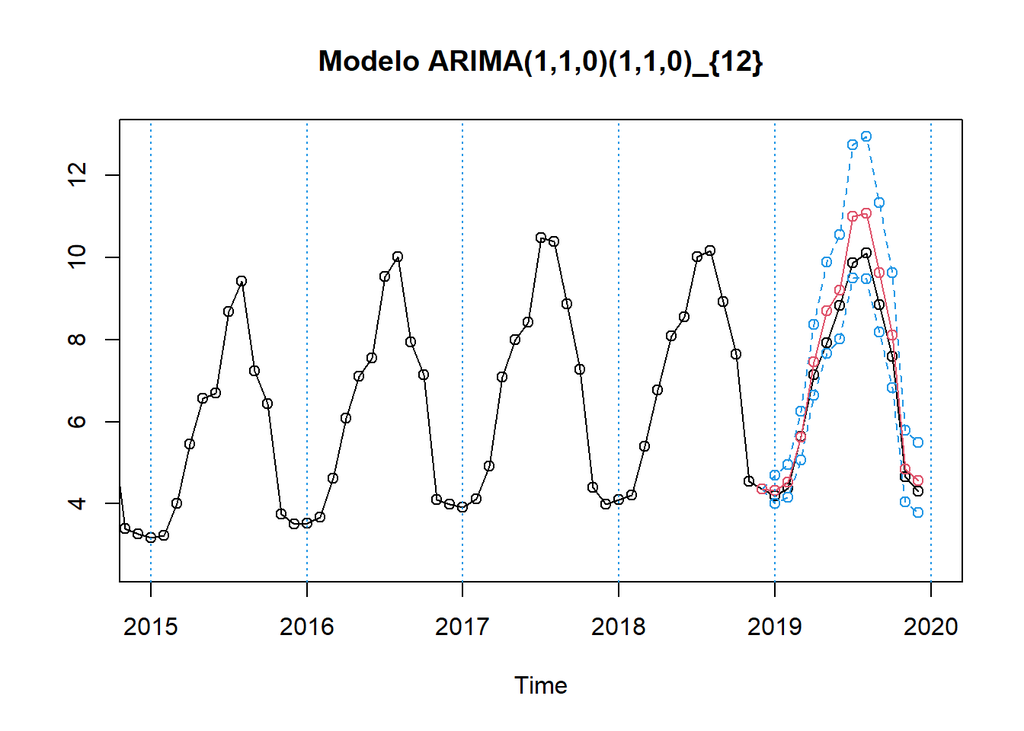

```r
pred=predict(mod1B2,n.ahead=12)
pr<-ts(c(tail(lnserie2,1),pred$pred),start=c(2018,12),freq=12)

se<-ts(c(0,pred$se),start=c(2018,12),freq=12)

#Intervalos de predicción
tl<-ts(exp(pr-1.96*se),start=c(2018,12),freq=12)
tu<-ts(exp(pr+1.96*se),start=c(2018,12),freq=12)
pr<-ts(exp(pr),start=c(2018,12),freq=12)             #predicciones en la escala original

#Plotear serie original y predicciones entre 2015 y 2019
ts.plot(serie1,tl,tu,pr,lty=c(1,2,2,1),col=c(1,4,4,2),xlim=c(2018,12)[1]+c(-3,+2),type="o",main="Modelo ARIMA(1,1,0)(1,1,0)_{12}")
abline(v=(c(2018,12)[1]-3):(c(2018,12)[1]+2),lty=3,col=4)
```

```r
(previs=window(cbind(tl,pr,tu,serie1,error=round(serie1-pr,3)),start=c(2018,12)))
```

```
##                tl        pr        tu    serie1  error
## Dec 2018 4.354821  4.354821  4.354821  4.354821  0.000
## Jan 2019 3.997729  4.330593  4.691174  4.195429 -0.135
## Feb 2019 4.155051  4.534729  4.949101  4.380646 -0.154
## Mar 2019 5.057323  5.623910  6.253974  5.648819  0.025
## Apr 2019 6.635887  7.451077  8.366410  7.146033 -0.305
## May 2019 7.655217  8.699503  9.886245  7.919204 -0.780
## Jun 2019 8.019050  9.198557 10.551555  8.833017 -0.366
## Jul 2019 9.505142 11.008322 12.749221  9.873562 -1.135
## Aug 2019 9.487814 11.082676 12.945627 10.120128 -0.963
## Sep 2019 8.175845  9.630197 11.343254  8.845508 -0.785
## Oct 2019 6.836056  8.115243  9.633798  7.590529 -0.525
## Nov 2019 4.050935  4.845358  5.795574  4.653320 -0.192
## Dec 2019 3.781600  4.555885  5.488705  4.304373 -0.252
```

```r
obs=window(serie1,start=c(2018,12))
(mod.EQM1=sqrt(sum(((obs-pr)/obs)^2)/12))
```

```
## [1] 0.06804324
```

```r
(mod.EAM1=sum(abs(obs-pr)/obs)/12)
```

```
## [1] 0.06016528
```

```r
(mod.ML1=sum(tu-tl)/12)
```

```
## [1] 2.108083
```

#### Predicción a largo plazo

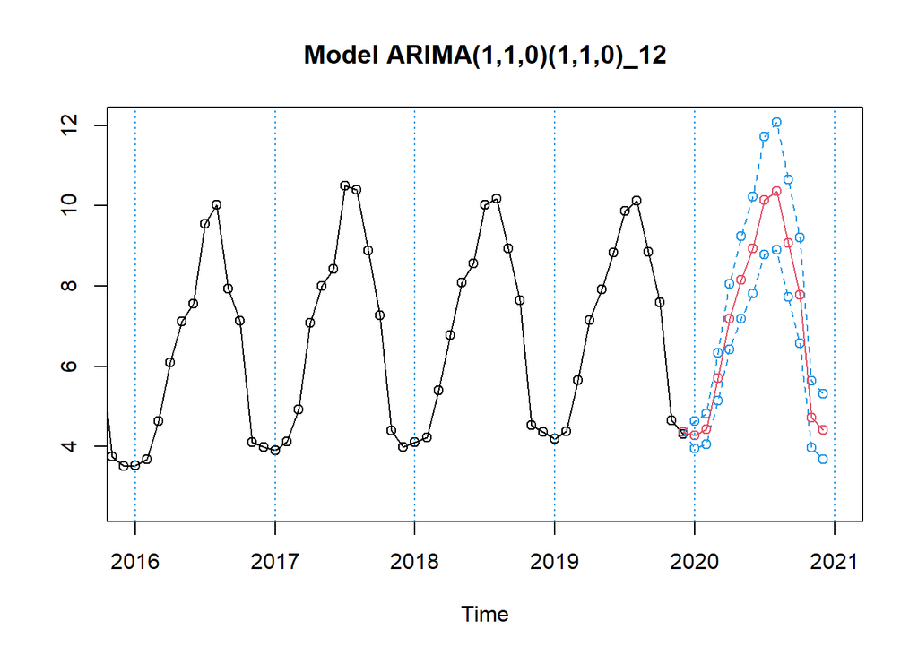

```r
pred=predict(mod1B,n.ahead=12)
pr<-ts(c(tail(lnserie,1),pred$pred),start=c(2019,12),freq=12)
se<-ts(c(0,pred$se),start=c(2019,12),freq=12)

tl1<-ts(exp(pr-1.96*se),start=c(2019,12),freq=12)
tu1<-ts(exp(pr+1.96*se),start=c(2019,12),freq=12)
pr1<-ts(exp(pr),start=c(2019,12),freq=12)

ts.plot(serie1,tl1,tu1,pr1,lty=c(1,2,2,1),col=c(1,4,4,2),xlim=c(c(2018,12)[1]-2,c(2018,12)[1]+3),type="o",main="Model ARIMA(1,1,0)(1,1,0)_12")
abline(v=(c(2018,12)[1]-2):(c(2018,12)[1]+3),lty=3,col=4)
```

```r
(previs1=window(cbind(tl1,pr1,tu1),start=c(2019,12)))
```

```
##               tl1       pr1       tu1
## Dec 2019 4.354821  4.354821  4.354821
## Jan 2020 3.955751  4.280124  4.631096
## Feb 2020 4.055039  4.419311  4.816307
## Mar 2020 5.137894  5.704137  6.332786
## Apr 2020 6.413912  7.188233  8.056034
## May 2020 7.189510  8.153420  9.246562
## Jun 2020 7.815257  8.944508 10.236927
## Jul 2020 8.780332 10.144285 11.720116
## Aug 2020 8.897508 10.366271 12.077491
## Sep 2020 7.724409  9.073619 10.658493
## Oct 2020 6.573383  7.780989  9.210445
## Nov 2020 3.960409  4.722832  5.632030
## Dec 2020 3.678381  4.417627  5.305440
```

### 8.2.2 Modelo 2B

#### Estabilidad del modelo

```r
(mod2B=arima(lnserie1,order=c(1,1,0),seasonal=list(order=c(0,1,1),period=12)))
```

```
##
## Call:
## arima(x = lnserie1, order = c(1, 1, 0), seasonal = list(order = c(0, 1, 1),
##     period = 12))
##
## Coefficients:
##           ar1     sma1
##       -0.5586  -0.3217
## s.e.   0.0788   0.1051
##
## sigma^2 estimated as 0.001611:  log likelihood = 212.95,  aic = -419.89
```

```r
cat("Modelo mod2B \nT-ratios:",round(mod2B$coef/sqrt(diag(mod2B$var.coef)),2))
```

```
## Modelo mod2B
## T-ratios: -7.09 -3.06
```

```r
(mod2B2=arima(lnserie2,order=c(1,1,0),seasonal=list(order=c(0,1,1),period=12)))
```

```
##
## Call:
## arima(x = lnserie2, order = c(1, 1, 0), seasonal = list(order = c(0, 1, 1),
##     period = 12))
##
## Coefficients:
##           ar1     sma1
##       -0.5483  -0.4044
## s.e.   0.0841   0.1212
##
## sigma^2 estimated as 0.001649:  log likelihood = 189.73,  aic = -373.46
```

```r
cat("Modelo mod2B2 \nT-ratios:",round(mod2B2$coef/sqrt(diag(mod2B2$var.coef)),2))
```

```
## Modelo mod2B2
## T-ratios: -6.52 -3.34
```

**Observaciones**  
Vemos que los coeficientes de los modelos son:  
- menores que uno en valor absoluto  
- no varían mucho entre los dos ajustes (con y sin los datos de 2019)  
- son del mismo signo respectivamente entre los dos ajustes  
- son significativos  
Es un modelo estable.

#### Predicción out-of-sample

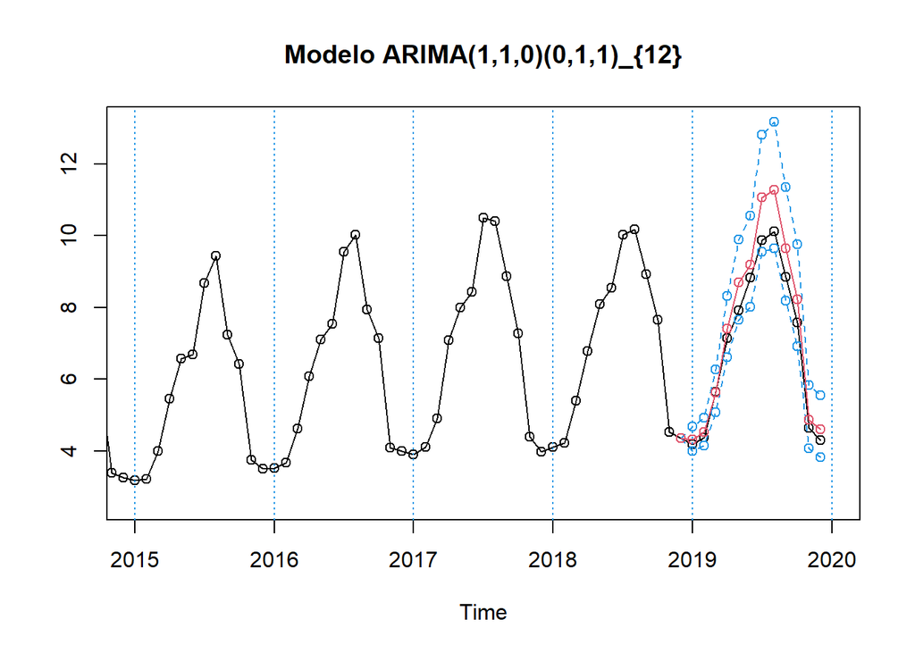

```r
pred=predict(mod2B2,n.ahead=12)
pr<-ts(c(tail(lnserie2,1),pred$pred),start=c(2018,12),freq=12)

se<-ts(c(0,pred$se),start=c(2018,12),freq=12)

#Intervalos de predicción
tl<-ts(exp(pr-1.96*se),start=c(2018,12),freq=12)
tu<-ts(exp(pr+1.96*se),start=c(2018,12),freq=12)
pr<-ts(exp(pr),start=c(2018,12),freq=12)             #predicciones en la escala original

#Plotear serie original y predicciones entre 2015 y 2019
ts.plot(serie1,tl,tu,pr,lty=c(1,2,2,1),col=c(1,4,4,2),xlim=c(2018,12)[1]+c(-3,+2),type="o",main="Modelo ARIMA(1,1,0)(0,1,1)_{12}")
abline(v=(c(2018,12)[1]-3):(c(2018,12)[1]+2),lty=3,col=4)
```

```r
(previs=window(cbind(tl,pr,tu,serie1,error=round(serie1-pr,3)),start=c(2018,12)))
```

```
##                tl        pr        tu    serie1  error
## Dec 2018 4.354821  4.354821  4.354821  4.354821  0.000
## Jan 2019 3.997186  4.328333  4.686914  4.195429 -0.133
## Feb 2019 4.144901  4.523169  4.935959  4.380646 -0.143
## Mar 2019 5.071813  5.638336  6.268139  5.648819  0.010
## Apr 2019 6.606493  7.417245  8.327494  7.146033 -0.271
## May 2019 7.657346  8.700465  9.885682  7.919204 -0.781
## Jun 2019 8.019706  9.198630 10.550860  8.833017 -0.366
## Jul 2019 9.559681 11.070620 12.820367  9.873562 -1.197
## Aug 2019 9.649028 11.270658 13.164821 10.120128 -1.151
## Sep 2019 8.186869  9.643014 11.358155  8.845508 -0.798
## Oct 2019 6.921554  8.216844  9.754531  7.590529 -0.626
## Nov 2019 4.075130  4.874438  5.830524  4.653320 -0.221
## Dec 2019 3.829811  4.614199  5.559237  4.304373 -0.310
```

```r
obs=window(serie1,start=c(2018,12))
(mod.EQM1=sqrt(sum(((obs-pr)/obs)^2)/12))
```

```
## [1] 0.07357051
```

```r
(mod.EAM1=sum(abs(obs-pr)/obs)/12)
```

```
## [1] 0.06426358
```

```r
(mod.ML1=sum(tu-tl)/12)
```

```
## [1] 2.118597
```

#### Predicción a largo plazo

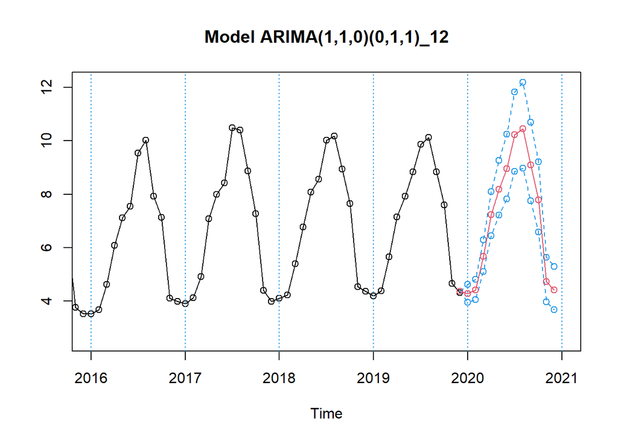

```r
pred=predict(mod2B,n.ahead=12)
pr<-ts(c(tail(lnserie,1),pred$pred),start=c(2019,12),freq=12)
se<-ts(c(0,pred$se),start=c(2019,12),freq=12)

tl1<-ts(exp(pr-1.96*se),start=c(2019,12),freq=12)
tu1<-ts(exp(pr+1.96*se),start=c(2019,12),freq=12)
pr1<-ts(exp(pr),start=c(2019,12),freq=12)

ts.plot(serie1,tl1,tu1,pr1,lty=c(1,2,2,1),col=c(1,4,4,2),xlim=c(c(2018,12)[1]-2,c(2018,12)[1]+3),type="o",main="Model ARIMA(1,1,0)(0,1,1)_12")
abline(v=(c(2018,12)[1]-2):(c(2018,12)[1]+3),lty=3,col=4)
```

```r
(previs1=window(cbind(tl1,pr1,tu1),start=c(2019,12)))
```

```
##               tl1       pr1       tu1
## Dec 2019 4.354821  4.354821  4.354821
## Jan 2020 3.953626  4.277204  4.627266
## Feb 2020 4.053376  4.417351  4.814008
## Mar 2020 5.111256  5.673934  6.298554
## Apr 2020 6.450017  7.228454  8.100838
## May 2020 7.211904  8.178353  9.274313
## Jun 2020 7.826950  8.957740 10.251899
## Jul 2020 8.863051 10.239663 11.830090
## Aug 2020 8.977819 10.459867 12.186569
## Sep 2020 7.750404  9.104226 10.694531
## Oct 2020 6.582982  7.792514  9.224281
## Nov 2020 3.965164  4.728635  5.639108
## Dec 2020 3.671014  4.408945  5.295212
```

### 8.2.3 Modelo 4B

#### Estabilidad del modelo

```r
(mod4B=arima(lnserie1,order=c(0,1,1),seasonal=list(order=c(1,1,0),period=12)))
```

```
##
## Call:
## arima(x = lnserie1, order = c(0, 1, 1), seasonal = list(order = c(1, 1, 0),
##     period = 12))
##
## Coefficients:
##           ma1     sar1
##       -0.6545  -0.3466
## s.e.   0.0752   0.0930
##
## sigma^2 estimated as 0.001544:  log likelihood = 215.25,  aic = -424.5
```

```r
cat("Modelo mod4B \nT-ratios:",round(mod4B$coef/sqrt(diag(mod4B$var.coef)),2))
```

```
## Modelo mod4B
## T-ratios: -8.7 -3.73
```

```r
(mod4B2=arima(lnserie2,order=c(0,1,1),seasonal=list(order=c(1,1,0),period=12)))
```

```
##
## Call:
## arima(x = lnserie2, order = c(0, 1, 1), seasonal = list(order = c(1, 1, 0),
##     period = 12))
##
## Coefficients:
##           ma1     sar1
##       -0.6542  -0.4108
## s.e.   0.0801   0.1000
##
## sigma^2 estimated as 0.001585:  log likelihood = 191.71,  aic = -377.42
```

```r
cat("Modelo mod4B2 \nT-ratios:",round(mod4B2$coef/sqrt(diag(mod4B2$var.coef)),2))
```

```
## Modelo mod4B2
## T-ratios: -8.17 -4.11
```

**Observaciones**  
Vemos que los coeficientes de los modelos son:  
- menores que uno en valor absoluto  
- no varían mucho entre los dos ajustes (con y sin los datos de 2019)  
- son del mismo signo respectivamente entre los dos ajustes  
- son significativos  
Es un modelo estable.

#### Predicción out-of-sample

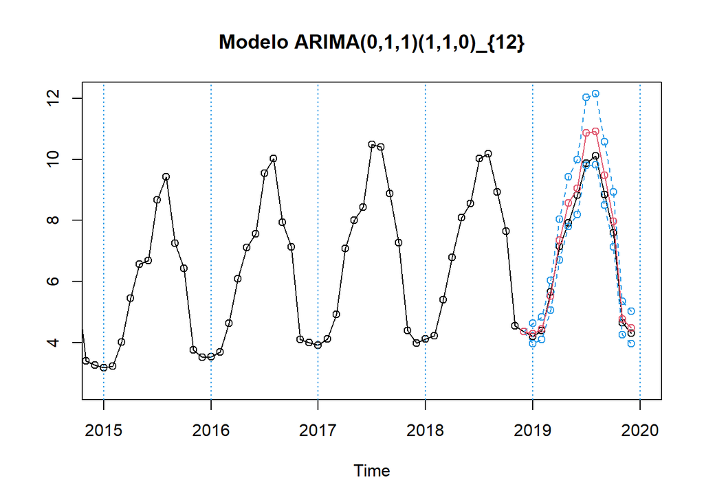

```r
pred=predict(mod4B2,n.ahead=12)
pr<-ts(c(tail(lnserie2,1),pred$pred),start=c(2018,12),freq=12)

se<-ts(c(0,pred$se),start=c(2018,12),freq=12)

#Intervalos de predicción
tl<-ts(exp(pr-1.96*se),start=c(2018,12),freq=12)
tu<-ts(exp(pr+1.96*se),start=c(2018,12),freq=12)
pr<-ts(exp(pr),start=c(2018,12),freq=12)             #predicciones en la escala original

#Plotear serie original y predicciones entre 2015 y 2019
ts.plot(serie1,tl,tu,pr,lty=c(1,2,2,1),col=c(1,4,4,2),xlim=c(2018,12)[1]+c(-3,+2),type="o",main="Modelo ARIMA(0,1,1)(1,1,0)_{12}")
abline(v=(c(2018,12)[1]-3):(c(2018,12)[1]+2),lty=3,col=4)
```

```r
(previs=window(cbind(tl,pr,tu,serie1,error=round(serie1-pr,3)),start=c(2018,12)))
```

```
##                tl        pr        tu    serie1  error
## Dec 2018 4.354821  4.354821  4.354821  4.354821  0.000
## Jan 2019 3.960306  4.281702  4.629181  4.195429 -0.086
## Feb 2019 4.093620  4.445951  4.828606  4.380646 -0.065
## Mar 2019 5.065398  5.525066  6.026448  5.648819  0.124
## Apr 2019 6.707914  7.346661  8.046232  7.146033 -0.201
## May 2019 7.793958  8.569639  9.422519  7.919204 -0.650
## Jun 2019 8.200766  9.050931  9.989232  8.833017 -0.218
## Jul 2019 9.812686 10.869287 12.039658  9.873562 -0.996
## Aug 2019 9.829811 10.926438 12.145407 10.120128 -0.806
## Sep 2019 8.502522  9.483154 10.576888  8.845508 -0.638
## Oct 2019 7.125280  7.973230  8.922091  7.590529 -0.383
## Nov 2019 4.244764  4.765107  5.349236  4.653320 -0.112
## Dec 2019 3.967662  4.467897  5.031201  4.304373 -0.164
```

```r
obs=window(serie1,start=c(2018,12))
(mod.EQM1=sqrt(sum(((obs-pr)/obs)^2)/12))
```

```
## [1] 0.05442498
```

```r
(mod.EAM1=sum(abs(obs-pr)/obs)/12)
```

```
## [1] 0.04644155
```

```r
(mod.ML1=sum(tu-tl)/12)
```

```
## [1] 1.475168
```

#### Predicción a largo plazo

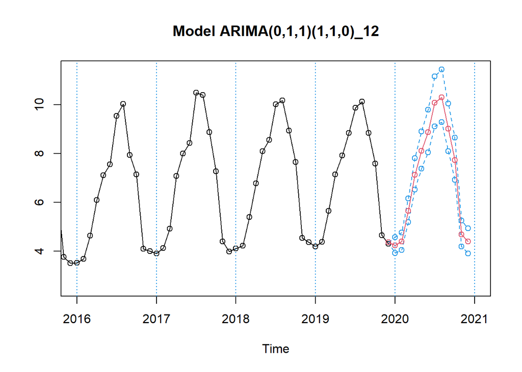

```r
pred=predict(mod4B,n.ahead=12)
pr<-ts(c(tail(lnserie,1),pred$pred),start=c(2019,12),freq=12)
se<-ts(c(0,pred$se),start=c(2019,12),freq=12)

tl1<-ts(exp(pr-1.96*se),start=c(2019,12),freq=12)
tu1<-ts(exp(pr+1.96*se),start=c(2019,12),freq=12)
pr1<-ts(exp(pr),start=c(2019,12),freq=12)

ts.plot(serie1,tl1,tu1,pr1,lty=c(1,2,2,1),col=c(1,4,4,2),xlim=c(c(2018,12)[1]-2,c(2018,12)[1]+3),type="o",main="Model ARIMA(0,1,1)(1,1,0)_12")
abline(v=(c(2018,12)[1]-2):(c(2018,12)[1]+3),lty=3,col=4)
```

```r
(previs1=window(cbind(tl1,pr1,tu1),start=c(2019,12)))
```

```
##               tl1       pr1       tu1
## Dec 2019 4.354821  4.354821  4.354821
## Jan 2020 3.917980  4.231679  4.570494
## Feb 2020 4.049635  4.393463  4.766484
## Mar 2020 5.184680  5.648754  6.154367
## Apr 2020 6.518375  7.130549  7.800215
## May 2020 7.380978  8.105409  8.900942
## Jun 2020 8.053206  8.876480  9.783916
## Jul 2020 9.116646 10.084602 11.155330
## Aug 2020 9.282031 10.303038 11.436354
## Sep 2020 8.098161  9.019020 10.044591
## Oct 2020 6.921838  7.733949  8.641343
## Nov 2020 4.181841  4.687211  5.253653
## Dec 2020 3.906131  4.391613  4.937434
```

### 8.2.4 Modelo 5B

#### Estabilidad del modelo

```r
(mod5B=arima(lnserie1,order=c(0,1,1),seasonal=list(order=c(0,1,1),period=12)))
```

```
##
## Call:
## arima(x = lnserie1, order = c(0, 1, 1), seasonal = list(order = c(0, 1, 1),
##     period = 12))
##
## Coefficients:
##           ma1     sma1
##       -0.6482  -0.3484
## s.e.   0.0779   0.1017
##
## sigma^2 estimated as 0.001552:  log likelihood = 214.96,  aic = -423.93
```

```r
cat("Modelo mod5B \nT-ratios:",round(mod5B$coef/sqrt(diag(mod5B$var.coef)),2))
```

```
## Modelo mod5B
## T-ratios: -8.32 -3.43
```

```r
(mod5B2=arima(lnserie2,order=c(0,1,1),seasonal=list(order=c(0,1,1),period=12)))
```

```
##
## Call:
## arima(x = lnserie2, order = c(0, 1, 1), seasonal = list(order = c(0, 1, 1),
##     period = 12))
##
## Coefficients:
##           ma1     sma1
##       -0.6442  -0.4390
## s.e.   0.0854   0.1215
##
## sigma^2 estimated as 0.001583:  log likelihood = 191.6,  aic = -377.2
```

```r
cat("Modelo mod5B2 \nT-ratios:",round(mod5B2$coef/sqrt(diag(mod5B2$var.coef)),2))
```

```
## Modelo mod5B2
## T-ratios: -7.54 -3.61
```

**Observaciones**  
Vemos que los coeficientes de los modelos son:  
- menores que uno en valor absoluto  
- no varían mucho entre los dos ajustes (con y sin los datos de 2019)  
- son del mismo signo respectivamente entre los dos ajustes  
- son significativos  
Es un modelo estable.

#### Predicción out-of-sample

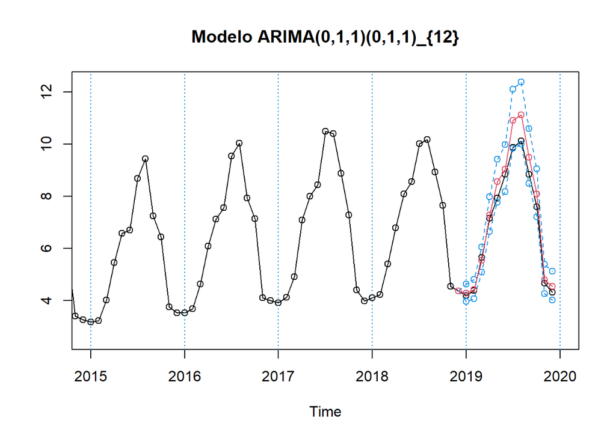

```r
pred=predict(mod5B2,n.ahead=12)
pr<-ts(c(tail(lnserie2,1),pred$pred),start=c(2018,12),freq=12)

se<-ts(c(0,pred$se),start=c(2018,12),freq=12)

#Intervalos de predicción
tl<-ts(exp(pr-1.96*se),start=c(2018,12),freq=12)
tu<-ts(exp(pr+1.96*se),start=c(2018,12),freq=12)
pr<-ts(exp(pr),start=c(2018,12),freq=12)             #predicciones en la escala original

#Plotear serie original y predicciones entre 2015 y 2019
ts.plot(serie1,tl,tu,pr,lty=c(1,2,2,1),col=c(1,4,4,2),xlim=c(2018,12)[1]+c(-3,+2),type="o",main="Modelo ARIMA(0,1,1)(0,1,1)_{12}")
abline(v=(c(2018,12)[1]-3):(c(2018,12)[1]+2),lty=3,col=4)
```

```r
(previs=window(cbind(tl,pr,tu,serie1,error=round(serie1-pr,3)),start=c(2018,12)))
```

```
##                tl        pr        tu    serie1  error
## Dec 2018 4.354821  4.354821  4.354821  4.354821  0.000
## Jan 2019 3.955090  4.275889  4.622708  4.195429 -0.080
## Feb 2019 4.071317  4.422678  4.804363  4.380646 -0.042
## Mar 2019 5.076575  5.539718  6.045116  5.648819  0.109
## Apr 2019 6.645004  7.282518  7.981193  7.146033 -0.136
## May 2019 7.772033  8.552761  9.411915  7.919204 -0.634
## Jun 2019 8.176598  9.033501  9.980208  8.833017 -0.200
## Jul 2019 9.834056 10.905932 12.094639  9.873562 -1.032
## Aug 2019 9.987556 11.116747 12.373605 10.120128 -0.997
## Sep 2019 8.485179  9.477972 10.586925  8.845508 -0.632
## Oct 2019 7.207810  8.078786  9.055008  7.590529 -0.488
## Nov 2019 4.259714  4.790359  5.387108  4.653320 -0.137
## Dec 2019 4.016486  4.531468  5.112480  4.304373 -0.227
```

```r
obs=window(serie1,start=c(2018,12))
(mod.EQM1=sqrt(sum(((obs-pr)/obs)^2)/12))
```

```
## [1] 0.0589101
```

```r
(mod.EAM1=sum(abs(obs-pr)/obs)/12)
```

```
## [1] 0.04924654
```

```r
(mod.ML1=sum(tu-tl)/12)
```

```
## [1] 1.497321
```

#### Predicción a largo plazo

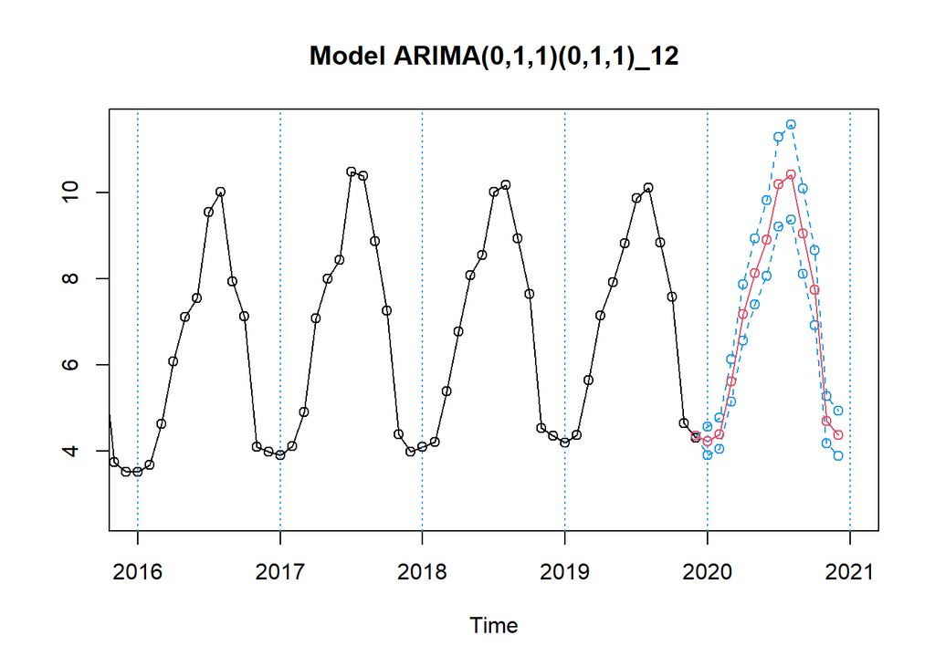

```r
pred=predict(mod5B,n.ahead=12)
pr<-ts(c(tail(lnserie,1),pred$pred),start=c(2019,12),freq=12)
se<-ts(c(0,pred$se),start=c(2019,12),freq=12)

tl1<-ts(exp(pr-1.96*se),start=c(2019,12),freq=12)
tu1<-ts(exp(pr+1.96*se),start=c(2019,12),freq=12)
pr1<-ts(exp(pr),start=c(2019,12),freq=12)

ts.plot(serie1,tl1,tu1,pr1,lty=c(1,2,2,1),col=c(1,4,4,2),xlim=c(c(2018,12)[1]-2,c(2018,12)[1]+3),type="o",main="Model ARIMA(0,1,1)(0,1,1)_12")
abline(v=(c(2018,12)[1]-2):(c(2018,12)[1]+3),lty=3,col=4)
```

```r
(previs1=window(cbind(tl1,pr1,tu1),start=c(2019,12)))
```

```
##               tl1       pr1       tu1
## Dec 2019 4.354821  4.354821  4.354821
## Jan 2020 3.913249  4.227355  4.566674
## Feb 2020 4.053237  4.398932  4.774112
## Mar 2020 5.155879  5.620228  6.126398
## Apr 2020 6.567245  7.188661  7.868878
## May 2020 7.400974  8.133679  8.938923
## Jun 2020 8.069358  8.902257  9.821127
## Jul 2020 9.209427 10.197516 11.291617
## Aug 2020 9.376291 10.419276 11.578278
## Sep 2020 8.122377  9.056989 10.099143
## Oct 2020 6.928393  7.751427  8.672232
## Nov 2020 4.186542  4.699064  5.274329
## Dec 2020 3.893092  4.383478  4.935634
```

# Parte 9: Selección del modelo final

## 9.1 Tabla de resumen

En esta tabla intentaremos recapitular todos los resultados significantes desde la validación de los modelos hasta los errores en las predicciones con tal de escoger uno de ellos.

```r
#MODELO 1
mod1B2=arima(lnserie2, order=c(1,1,0),seasonal=list(order=c(1,1,0),period=12))
model=mod1B2
pred=predict(mod1B2,n.ahead=12)
se<-ts(c(0,pred$se),start=c(2018,12),freq=12)
pr<-ts(c(tail(lnserie2,1),pred$pred),start=c(2018,12),freq=12)
tl<-ts(exp(pr-1.96*se),start=c(2018,12),freq=12)
tu<-ts(exp(pr+1.96*se),start=c(2018,12),freq=12)
pr<-ts(exp(pr),start=c(2018,12),freq=12)
mod.EQM1=sqrt(sum(((obs-pr)/obs)^2)/12)
mod.EAM1=sum(abs(obs-pr)/obs)/12
mod.ML1=sum(tu-tl)/12

model=mod1B
resumen1<-val1
colnames(resumen1)<-c("mod1B")
resumen1[16,1]=mod.EQM1
resumen1[17,1]=mod.EAM1
resumen1[18,1]=mod.ML1


#MODELO 2
mod2B2=arima(lnserie2, order=c(1,1,0),seasonal=list(order=c(0,1,1),period=12))
model=mod2B2
pred=predict(mod2B2,n.ahead=12)
se<-ts(c(0,pred$se),start=c(2018,12),freq=12)
pr<-ts(c(tail(lnserie2,1),pred$pred),start=c(2018,12),freq=12)
tl<-ts(exp(pr-1.96*se),start=c(2018,12),freq=12)
tu<-ts(exp(pr+1.96*se),start=c(2018,12),freq=12)
pr<-ts(exp(pr),start=c(2018,12),freq=12)
mod.EQM1=sqrt(sum(((obs-pr)/obs)^2)/12)
mod.EAM1=sum(abs(obs-pr)/obs)/12
mod.ML1=sum(tu-tl)/12

model=mod2B
resumen2<-val2
colnames(resumen2)<-c("mod2B")
resumen2[16,1]=mod.EQM1
resumen2[17,1]=mod.EAM1
resumen2[18,1]=mod.ML1

#MODELO 4
mod4B2=arima(lnserie2, order=c(0,1,1),seasonal=list(order=c(1,1,0),period=12))
model=mod4B2
pred=predict(mod4B2,n.ahead=12)
se<-ts(c(0,pred$se),start=c(2018,12),freq=12)
pr<-ts(c(tail(lnserie2,1),pred$pred),start=c(2018,12),freq=12)
tl<-ts(exp(pr-1.96*se),start=c(2018,12),freq=12)
tu<-ts(exp(pr+1.96*se),start=c(2018,12),freq=12)
pr<-ts(exp(pr),start=c(2018,12),freq=12)
mod.EQM1=sqrt(sum(((obs-pr)/obs)^2)/12)
mod.EAM1=sum(abs(obs-pr)/obs)/12
mod.ML1=sum(tu-tl)/12

model=mod4B
resumen3<-val4
colnames(resumen3)<-c("mod4B")
resumen3[16,1]=mod.EQM1
resumen3[17,1]=mod.EAM1
resumen3[18,1]=mod.ML1

#MODELO 5
mod5B2=arima(lnserie2, order=c(0,1,1),seasonal=list(order=c(0,1,1),period=12))
model=mod5B2
pred=predict(mod5B2,n.ahead=12)
se<-ts(c(0,pred$se),start=c(2018,12),freq=12)
pr<-ts(c(tail(lnserie2,1),pred$pred),start=c(2018,12),freq=12)
tl<-ts(exp(pr-1.96*se),start=c(2018,12),freq=12)
tu<-ts(exp(pr+1.96*se),start=c(2018,12),freq=12)
pr<-ts(exp(pr),start=c(2018,12),freq=12)
mod.EQM1=sqrt(sum(((obs-pr)/obs)^2)/12)
mod.EAM1=sum(abs(obs-pr)/obs)/12
mod.ML1=sum(tu-tl)/12

model=mod5B
resumen4<-val5
colnames(resumen4)<-c("mod5B")
resumen4[16,1]=mod.EQM1
resumen4[17,1]=mod.EAM1
resumen4[18,1]=mod.ML1


tablef<-cbind.data.frame(resumen1,resumen2,resumen3,resumen4)
```

```r
library(knitr)
kable(
  tablef,
  caption = "Resumen de Modelos",
  digits = 4,
  format = "html"
)
```

Resumen de Modelos

|  | mod1B | mod2B | mod4B | mod5B |
| --- | --- | --- | --- | --- |
| Shapiro-Wilks Normality p-value | 0.3150 | 0.2002 | 0.1655 | 0.0845 |
| Anderson-Darling p-value | 0.0852 | 0.0400 | 0.1030 | 0.0678 |
| Jarque-Bera p-value | 0.2557 | 0.2150 | 0.0565 | 0.0263 |
| Breusch-Pagan p-value | 0.8739 | 0.7844 | 0.8890 | 0.7783 |
| Durbin-Watson p-value | 0.8995 | 0.8615 | 0.7466 | 0.6781 |
| Ljung-Box (lag 1) p-value | 0.1619 | 0.2244 | 0.4546 | 0.5597 |
| Ljung-Box (lag 2) p-value | 0.0426 | 0.0710 | 0.2229 | 0.2438 |
| Ljung-Box (lag 3) p-value | 0.0626 | 0.1194 | 0.3734 | 0.4196 |
| Ljung-Box (lag4) p-value | 0.1185 | 0.2058 | 0.5358 | 0.5878 |
| Ljung-Box (lag 12) p-value | 0.0176 | 0.0156 | 0.1836 | 0.1063 |
| Ljung-Box (lag 24) p-value | 0.0083 | 0.0117 | 0.0920 | 0.0460 |
| Ljung-Box (lag 36) p-value | 0.0177 | 0.0329 | 0.2024 | 0.1267 |
| Ljung-Box (lag 48) p-value | 0.0053 | 0.0133 | 0.0356 | 0.0300 |
| Log Likelihood | 189.4310 | 189.7291 | 191.7095 | 191.6012 |
| AIC | -372.8620 | -373.4582 | -377.4191 | -377.2024 |
| RMSPE | 0.0680 | 0.0736 | 0.0544 | 0.0589 |
| MAPE | 0.0602 | 0.0643 | 0.0464 | 0.0492 |
| Mean Length | 2.1081 | 2.1186 | 1.4752 | 1.4973 |

**Observaciones**  
En la parte de los errores de nuestras diferentes predicciones vemos que el modelo 4 posee los valores más pequeños.  
Este dato junto con la parte de validación donde hemos observado que el modelo 4 era también el más adecuado nos lleva a nuestra decisión final.  
El modelo 4 es nuestro modelo escogido para ajustar la serie temporal del número de entrada de Turistas en España de 2009 a 2018 con predicciones hasta 2020.

## 9.2 Uso del algoritmo automático

```r
library(forecast)
auto.arima(lnserie)
```

```
## Series: lnserie
## ARIMA(0,1,1)(1,1,0)[12]
##
## Coefficients:
##           ma1     sar1
##       -0.6542  -0.4108
## s.e.   0.0801   0.1000
##
## sigma^2 = 0.001615:  log likelihood = 191.71
## AIC=-377.42   AICc=-377.19   BIC=-369.4
```

**Interpretación**  
Es justamente el modelo que hemos escogido.  
Hemos verificado que nuestro procedimiento y que nuestras conclusiones a los resultados obtenidos han sido correctas.  
Nuestro modelo teórico detrás de esta serie observada es, $ARIMA(0,1,1)(1,1,0)_{12}$:

$$(1 - \Phi_1 B^{12})(1 - B)(1 - B^{12})ln(X_t) = (1 + \theta_1 B)Z_t; Z_t
\sim N(0,0.001585)$$

con

$$\Phi_1 = -0.4108$$
$$\theta_1 = -0.6542$$

# Conclusión

El modelo seleccionado para este trabajo es el **ARIMA(0, 1, 1)(1, 1, 0)_{12}**, basado en las características de la serie temporal del turismo en España. Este modelo incluye una transformación logarítmica que estabiliza la varianza y captura con precisión los patrones de crecimiento y estacionalidad.

El modelo incorpora términos de diferenciación no estacional y estacional ($1 - B$ y $1 - B^{12}$) para eliminar la tendencia y los ciclos anuales. Además, incluye un componente autorregresivo estacional ($\Phi_1 = -0.4108$) para ajustar las dependencias temporales en ciclos de 12 meses, y un promedio móvil no estacional ($\theta_1 = -0.6542$) para corregir las fluctuaciones aleatorias a corto plazo. Esto permite capturar tanto las variaciones estacionales como la tendencia creciente.

El turismo en España muestra una marcada **estacionalidad multiplicativa**, donde las fluctuaciones son proporcionales al nivel general de la serie. A medida que el turismo crece a lo largo de los años, las variaciones estacionales también se amplifican, justificando la elección de un enfoque multiplicativo.